# (Video games data Exploration)

## Preliminary Wrangling

> This dataset contains a list of video games with sales greater than 100,000 copies.  
> Fields include  
> Rank - Ranking of overall sales  
> Name - The games name  
> Platform - Platform of the games release (i.e. PC,PS4, etc.)  
> Year - Year of the game's release  
> Genre - Genre of the game  
> Publisher - Publisher of the game  
> NA_Sales - Sales in North America (in millions)  
> EU_Sales - Sales in Europe (in millions)  
> JP_Sales - Sales in Japan (in millions)  
> Other_Sales - Sales in the rest of the world (in millions)  
> Global_Sales - Total worldwide sales.  
> There are 16,598 records.

```python
# import all packages and set plots to be embedded inline
import numpy as np
import pandas as pd
import matplotlib.pyplot as plt
import seaborn as sb

%matplotlib inline
```

> Load in your dataset and describe its properties through the questions below. Try and motivate your exploration goals through this section.

```python
games=pd.read_csv('video_games.csv')
games.head()
```

|  | Rank | Name | Platform | Year | Genre | Publisher | NA_Sales | EU_Sales | JP_Sales | Other_Sales | Global_Sales |
| --- | --- | --- | --- | --- | --- | --- | --- | --- | --- | --- | --- |
| 0 | 1 | Wii Sports | Wii | 2006 | Sports | Nintendo | 41.49 | 29.02 | 3.77 | 8.46 | 82.74 |
| 1 | 2 | Super Mario Bros. | NES | 1985 | Platform | Nintendo | 29.08 | 3.58 | 6.81 | 0.77 | 40.24 |
| 2 | 3 | Mario Kart Wii | Wii | 2008 | Racing | Nintendo | 15.85 | 12.88 | 3.79 | 3.31 | 35.82 |
| 3 | 4 | Wii Sports Resort | Wii | 2009 | Sports | Nintendo | 15.75 | 11.01 | 3.28 | 2.96 | 33.00 |
| 4 | 5 | Pokemon Red/Pokemon Blue | GB | 1996 | Role-Playing | Nintendo | 11.27 | 8.89 | 10.22 | 1.00 | 31.37 |

```python
games.info()
```

```
<class 'pandas.core.frame.DataFrame'>
RangeIndex: 16598 entries, 0 to 16597
Data columns (total 11 columns):
Rank            16598 non-null int64
Name            16598 non-null object
Platform        16598 non-null object
Year            16327 non-null object
Genre           16598 non-null object
Publisher       16540 non-null object
NA_Sales        16598 non-null float64
EU_Sales        16598 non-null float64
JP_Sales        16598 non-null float64
Other_Sales     16598 non-null float64
Global_Sales    16596 non-null float64
dtypes: float64(5), int64(1), object(5)
memory usage: 1.4+ MB
```

```python
games.shape
```

```
(16598, 11)
```

```python
#know if there is null values or no
games.isnull().sum()
```

[output not shown]

```python
#drop null values
games.dropna(inplace=True)
```

```python
#know data types of cols
games.dtypes
```

```
Rank              int64
Name             object
Platform         object
Year             object
Genre            object
Publisher        object
NA_Sales        float64
EU_Sales        float64
JP_Sales        float64
Other_Sales     float64
Global_Sales    float64
dtype: object
```

```python
games.describe()
```

|  | Rank | NA_Sales | EU_Sales | JP_Sales | Other_Sales | Global_Sales |
| --- | --- | --- | --- | --- | --- | --- |
| count | 16289.000000 | 16289.000000 | 16289.000000 | 16289.000000 | 16289.000000 | 16289.000000 |
| mean | 8289.665050 | 0.264763 | 0.147035 | 0.078862 | 0.048432 | 0.540969 |
| std | 4792.702183 | 0.822388 | 0.509101 | 0.311901 | 0.190094 | 1.567432 |
| min | 1.000000 | 0.000000 | 0.000000 | 0.000000 | 0.000000 | 0.010000 |
| 25% | 4132.000000 | 0.000000 | 0.000000 | 0.000000 | 0.000000 | 0.060000 |
| 50% | 8291.000000 | 0.080000 | 0.020000 | 0.000000 | 0.010000 | 0.170000 |
| 75% | 12439.000000 | 0.240000 | 0.110000 | 0.040000 | 0.040000 | 0.480000 |
| max | 16600.000000 | 41.490000 | 29.020000 | 10.220000 | 10.570000 | 82.740000 |

```python
#know all genre of video games
games['Genre'].unique()
```

```
array(['Sports', 'Platform', 'Racing', 'Role-Playing', 'Puzzle', 'Misc',
       'Shooter', 'Simulation', 'Action', 'Fighting', 'Adventure',
       'Strategy'], dtype=object)
```

```python
# if exits duplicate values
games.duplicated().sum()
```

```
0
```

```python
#drop rows if any two col have zero values from col Na or Jp or Eu
games.drop(games[((games['NA_Sales'] ==0)&(games['JP_Sales'] ==0)|(games['NA_Sales'] ==0)&(games['EU_Sales'] ==0)|(games['EU_Sales'] ==0)&(games['JP_Sales'] ==0))].index, inplace = True)
```

```python
#drop rows have year value == 2017 or 2020 becaues outlier or == adventure becaue in wrong value
games.drop(games[(games['Year'] =='2017')|(games['Year'] =="2020")|(games['Year'] =='Adventure')].index, inplace = True)
```

### What is/are the main feature(s) of interest in your dataset?

> the most intersting feature in dataset is Global_Sales of video game.

### What features in the dataset do you think will help support your investigation into your feature(s) of interest?

> I expect that Genre will have the strongest effect on each video game's sale. I also think that the release year of video game will have effects on the sales, though As the years go by, sales increase.

## Univariate Exploration

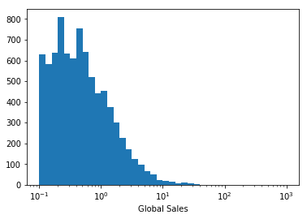

```python
bins = 10 ** np.arange(-1, 3+0.1, 0.1)
plt.hist(data = games, x = 'Global_Sales',bins=bins);
plt.xscale('log')
plt.xlabel('Global Sales');
```

```python
#take freq vlaues to make order in plot
sort=games['Genre'].value_counts()
sort=sort.index
```

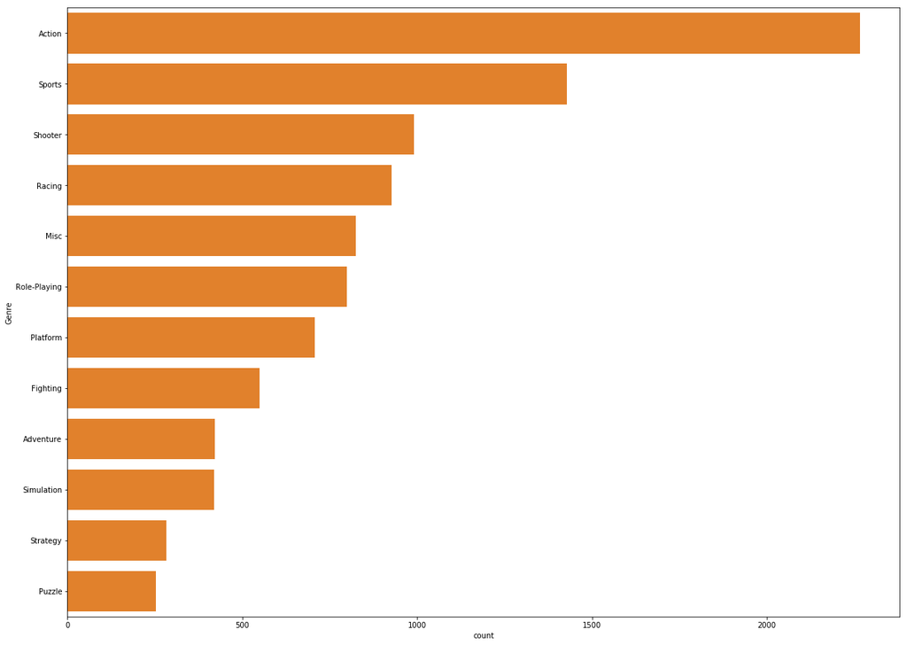

```python
plt.figure(figsize=[20,15])
color=sb.color_palette()[1]
sb.countplot(data=games,y='Genre',order=sort,color=color);
```

> The type of games most produced is action, followed by sports and shooting.

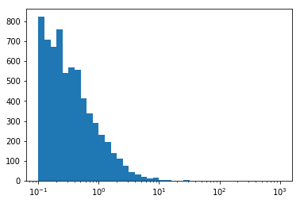

```python
bins = 10 ** np.arange(-1, 3+0.1, 0.1)
plt.hist(data = games, x = 'NA_Sales',bins=bins);
plt.xscale('log')
```

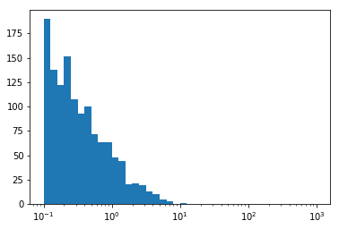

```python
bins = 10 ** np.arange(-1, 3+0.1, 0.1)
plt.hist(data = games, x = 'JP_Sales',bins=bins);

plt.xscale('log')
```

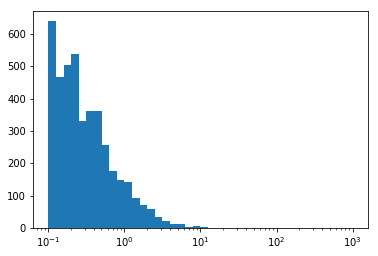

```python
bins = 10 ** np.arange(-1, 3+0.1, 0.1)
plt.hist(data = games, x = 'EU_Sales',bins=bins);

plt.xscale('log')
```

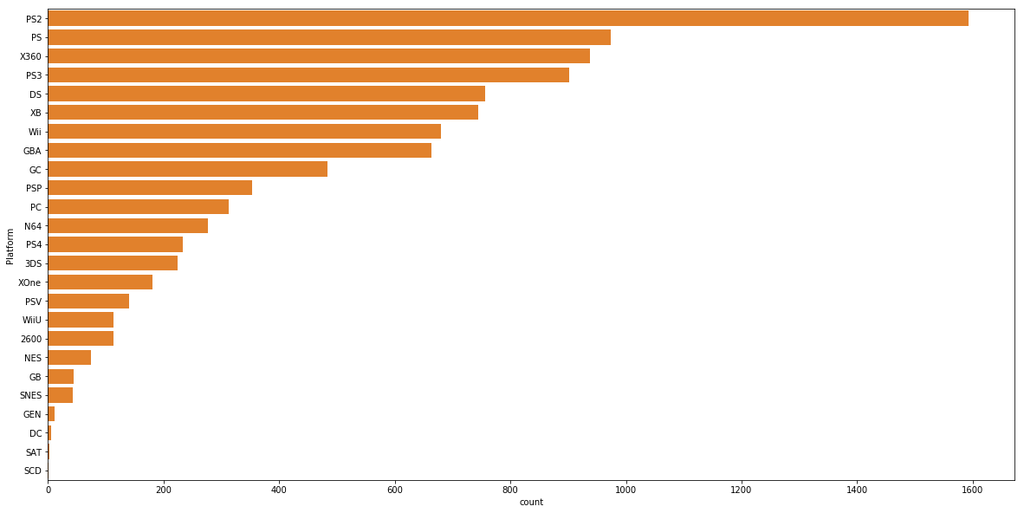

```python
plt.figure(figsize=[20,10])
sort=games['Platform'].value_counts().index
sb.countplot(data=games,y='Platform',order=sort,color=color);
```

> consider ps2 platform is the most platform video games produce on it.

### Discuss the distribution(s) of your variable(s) of interest. Were there any unusual points? Did you need to perform any transformations?

> The global Sales variable took on a large range of values, so I looked at the data using a log transform. Under the transformation, the data looked skewed.

### Of the features you investigated, were there any unusual distributions? Did you perform any operations on the data to tidy, adjust, or change the form of the data? If so, why did you do this?

> this is no unusual distributions of any feature but all feature of sales have same distributions is skewed,i did not do any operations but becuse large range make log transform.

## Bivariate Exploration

> In this section, investigate relationships between pairs of variables in your data. Make sure the variables that you cover here have been introduced in some fashion in the previous section (univariate exploration).

```python
df=games[(games['Platform'] == 'PS4') |(games['Platform'] == 'PS2')|(games['Platform'] == 'PC')|(games['Platform'] == 'Wii')|(games['Platform'] == 'PS')|(games['Platform'] == 'DS')|(games['Platform'] == 'X360')|(games['Platform'] == 'PS3')]
dfx=df[(df['Publisher'] == 'Nintendo')|(df['Publisher'] == 'Electronic Arts')|(df['Publisher'] == 'Activision')|(df['Publisher'] == 'Sony Computer Entertainment')|(games['Publisher'] == 'Ubisoft')]
```

```
E:\New folder (4)\lib\site-packages\ipykernel_launcher.py:2: UserWarning: Boolean Series key will be reindexed to match DataFrame index.
```

> in this cell above extract most popular platform and publisher to investigate on them.

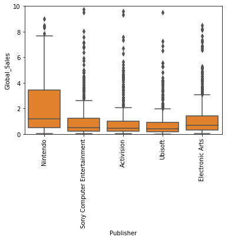

```python
sb.boxplot(data =dfx, x = 'Publisher', y = 'Global_Sales',color=color);
plt.ylim((0,10))
plt.xticks(rotation=90);
plt.figure(figsize=[20,5]);
```

> considre Nintendo is the most publisher have sales from video games.

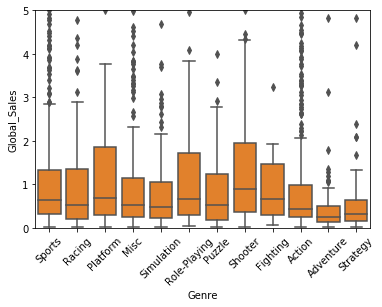

```python
sb.boxplot(data =dfx, x = 'Genre', y = 'Global_Sales',color=color);
plt.ylim((0,5))
plt.xticks(rotation=45);
plt.figure(figsize=[20,5]);
```

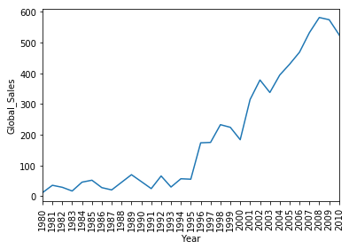

```python
year=games.groupby('Year')['Global_Sales'].sum().reset_index()

sb.lineplot(data=year,x='Year',y='Global_Sales');
plt.xlim((0,30))
plt.xticks(rotation=90);
```

```python
#function use to make heatmap use any values you need
def heatMap(x,y):
    ct_counts = dfx.groupby([x, y]).size()
    # Use Series.reset_index() to convert a series into a dataframe object
    ct_counts = ct_counts.reset_index(name='count')
    # Use DataFrame.pivot() to rearrange the data, to have vehicle class on rows
    return ct_counts.pivot(index = x, columns = y, values = 'count')
```

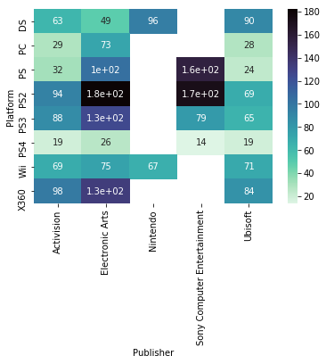

```python
ct_counts=heatMap('Platform','Publisher')
sb.heatmap(ct_counts, annot = True,cmap='mako_r');
```

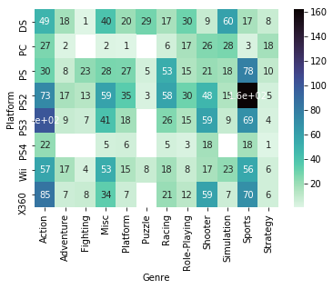

```python
ct_counts = heatMap('Platform', 'Genre')

sb.heatmap(ct_counts, annot = True,cmap = 'mako_r');
```

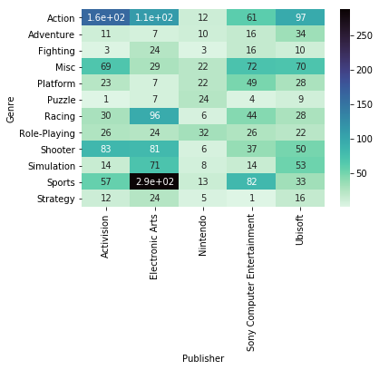

```python
ct_counts = dfx.groupby(['Publisher', 'Genre']).size()

# Use Series.reset_index() to convert a series into a dataframe object
ct_counts = ct_counts.reset_index(name='count')

# Use DataFrame.pivot() to rearrange the data, to have vehicle class on rows
ct_counts = ct_counts.pivot(index ='Genre' , columns = 'Publisher', values = 'count')

sb.heatmap(ct_counts, annot = True,cmap='mako_r');
```

### Talk about some of the relationships you observed in this part of the investigation. How did the feature(s) of interest vary with other features in the dataset?

> relationship between global sales and year is that increase sales with increae years,considre shooter games have most sales In comparison with anthor types (genre),and Nintendo publisher is the most publishers have global sales.

### Did you observe any interesting relationships between the other features (not the main feature(s) of interest)?

> publisher Electroinc arts produce at most video games of genre sports and action ,while activision produce at most video games of genre action,ps2 platform most video games on it from gnere sports,while ps3 have action video games.

## Multivariate Exploration

> At the end of your report, make sure that you export the notebook as an html file from the `File > Download as... > HTML` menu. Make sure you keep track of where the exported file goes, so you can put it in the same folder as this notebook for project submission. Also, make sure you remove all of the quote-formatted guide notes like this one before you finish your report!

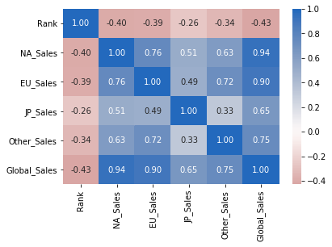

```python
sb.heatmap(games.corr(), annot = True, fmt = '.2f', cmap = 'vlag_r', center = 0)
```

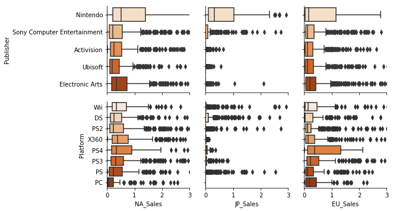

```python
g = sb.PairGrid(data = dfx, x_vars = ['NA_Sales', 'JP_Sales', 'EU_Sales'],
                y_vars = ['Publisher','Platform'], palette="Oranges")
g.map(sb.boxplot)
g.set(xlim=(0, 3))
```

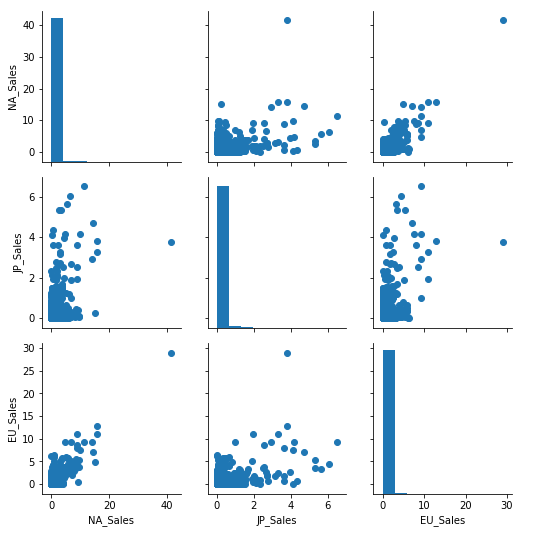

```python
g = sb.PairGrid(data = df, vars = ['NA_Sales', 'JP_Sales', 'EU_Sales'])
g.map_diag(plt.hist)
g.map_offdiag(plt.scatter)
```

[output not shown]

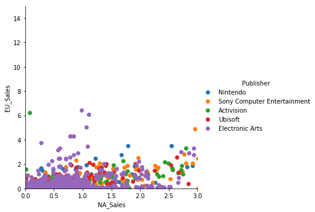

```python
g = sb.FacetGrid(data = dfx, hue = 'Publisher', size = 5)
g.map(plt.scatter, 'NA_Sales', 'EU_Sales')
g.add_legend()
g.set(xlim=(0, 3))
g.set(ylim=(0, 15))
```

```
E:\New folder (4)\lib\site-packages\seaborn\axisgrid.py:316: UserWarning: The `size` parameter has been renamed to `height`; please update your code.
  warnings.warn(msg, UserWarning)
```

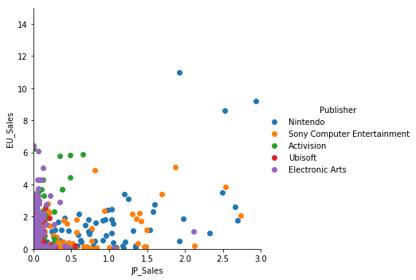

```python
g = sb.FacetGrid(data = dfx, hue = 'Publisher', size = 5)
g.map(plt.scatter, 'JP_Sales', 'EU_Sales')
g.add_legend()
g.set(xlim=(0, 3))
g.set(ylim=(0, 15))
```

```
E:\New folder (4)\lib\site-packages\seaborn\axisgrid.py:316: UserWarning: The `size` parameter has been renamed to `height`; please update your code.
  warnings.warn(msg, UserWarning)
```

```
(0, 20)
```

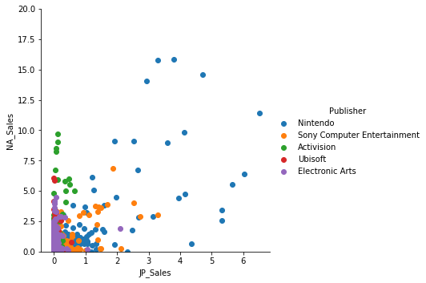

```python
g = sb.FacetGrid(data = dfx, hue = 'Publisher', size = 5)
g.map(plt.scatter, 'JP_Sales', 'NA_Sales')
g.add_legend()
plt.ylim((0,20))
```

### Talk about some of the relationships you observed in this part of the investigation. Were there features that strengthened each other in terms of looking at your feature(s) of interest?

> This may indicate that sales of games are more in Europe and North America, so the relationship between them and global sales is strong because it is a collection of all those salesو and this shows that Japan's sales are few and other regions are appropriate for those regions.

### Were there any interesting or surprising interactions between features?

> the most interesting that Nintendo publisher has most sales in all regions from north america ,europe and japan. but there is some publisher have favoutie region like electroinc arts has most sales in Na rather then other regions.